# Model-based IC score

Author

Yong-Hao Pua

Published

August 15, 2025

## Goals

This report details the statistical codes and main results for the paper, “Development, validity, and utility of a model-based intrinsic capacity composite score in community-dwelling older persons”.

```r
rm(list=ls())
library(tidyverse)
library(rms)
library(janitor)
library(glue)
library(readxl)
library(here)
library(pROC)
library(dcurves)
library(naniar)
library(foreach)
library(doParallel)
load("ippts.RData")
```

# Sample size calculation

Sample size calculation is based on formulae developed by [Riley and colleagues](https://doi.org/10.1002/sim.9025)

Assumptions  
(i) 30% of the cohort had an impaired composite IC score  
(ii) 15 predictor parameters  
(iii) a concordance index (c-statistic) of 0.80

```r
# Criterion 4 formula by Riley et al
round(exp((-0.508 + 0.259 * log(0.3) + 0.504 * log(15) - log(0.05))/0.544),0)
```

```
[1] 671
```

# Missing data: single imputation

Given the low (1%) missing data rate for the individual IC component measures, we impute missing IC component values using single predictive mean matching imputation.

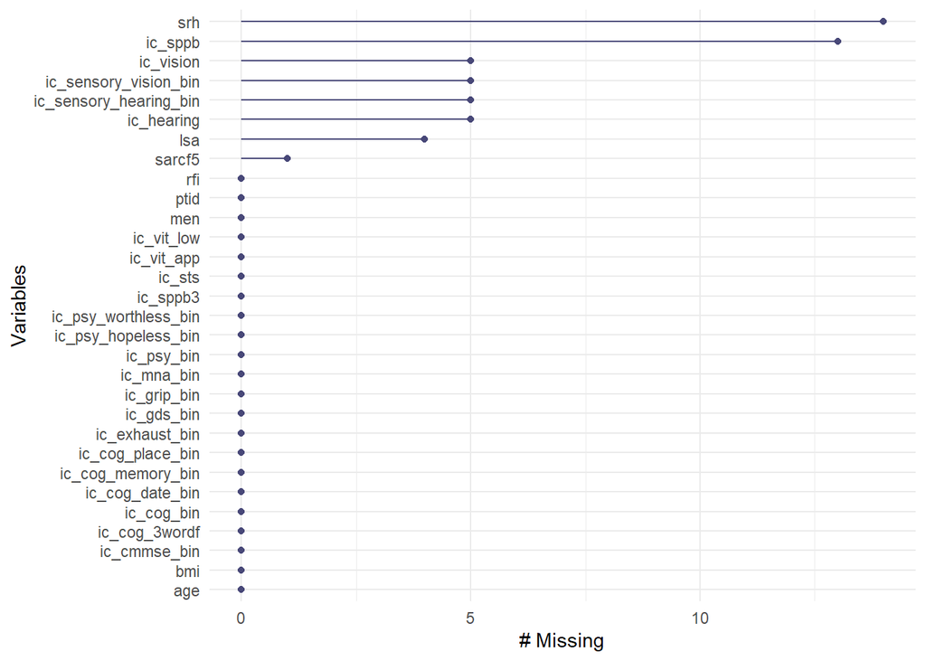

```r
gg_miss_var(ippts) # visualize missing data rate
```

```r
set.seed(1235)
imp <- aregImpute(
  ~ ic_cog_3wordf +  ic_cog_date_bin + ic_cog_place_bin + ic_sts +
    ic_sppb + ic_sts + ic_sensory_vision_bin + ic_sensory_hearing_bin + age + bmi + men,
  data = ippts, n.impute = 1)
```

```
Iteration 1
Iteration 2
Iteration 3
Iteration 4
```

```r
for(x in Cs(ic_sppb, ic_sensory_vision_bin, ic_sensory_hearing_bin))
   ippts[[x]][is.na(ippts[[x]])] <- imp$imputed[[x]]

ippts_cleaned <-
  ippts %>%
  mutate(ic_sppb3 = cut2(ic_sppb, c(2.5, 9.5)) %>% as.factor %>% as.numeric  %>% {. -1}) %>%
  mutate(ic_sts_bin = ifelse(ic_sts>12.5, 1, 0)) %>%
  mutate(ic_vit_app_bin = ifelse(ic_vit_app ==2, 1, 0)) %>%
  mutate(ic_vit_low_bin = ifelse(ic_vit_low ==0, 0, 1)) %>%
  mutate(ic_vit_bin = ifelse(ic_vit_app_bin == 1 & ic_vit_low_bin == 1, 1, 0)) %>%
  mutate(ic_sensory_bin = ifelse(ic_sensory_vision_bin ==1 & ic_sensory_hearing_bin==1, 1, 0 )) %>%
  # Step 1 scores
  mutate(icsum_5 = ic_cog_bin + ic_sts_bin + ic_vit_bin + ic_psy_bin + ic_sensory_bin) %>%
  # Step 2 scores
  mutate(ic2sum_8  =
           # Cognition
           ic_cmmse_bin + ic_cog_memory_bin +
           # Locomotion
           ic_sppb3 +
           # Vitality
           ic_grip_bin + ic_mna_bin +
           # Psychological
           ic_gds_bin + ic_exhaust_bin) %>%
  mutate (ic_impaired = ifelse(ic2sum_8 < 7, 1, 0)) %>%
  mutate(ic2sum_8_collapsed = ifelse(ic2sum_8 <=2 , 2, ic2sum_8))
```

# Model Fitting

Fit the proportional odds model (POM) on the Step 2 composite IC scores  
Generate model-based composite IC score from fitted POM (using rms::`Mean` function)

```r
mod_ics2 <- lrm(ic2sum_8 ~
                  ic_cog_3wordf  + ic_cog_date_bin + ic_cog_place_bin  +
                  rcs(ic_sts,3) +
                  ic_sensory_vision_bin + ic_sensory_hearing_bin +
                  ic_vit_app +  ic_vit_low +
                  ic_psy_hopeless_bin    +  ic_psy_worthless_bin,
                x = T, y = T, data = ippts_cleaned)

ippts_cleaned$ic_mod = Mean(mod_ics2)(predict(mod_ics2)) # Model-based composite IC

ippts_cleaned.dd <- datadist(ippts_cleaned, adjto.cat = 'first' )
options(datadist="ippts_cleaned.dd")
```

## PO Assumption

**Score residual plots**

Using score residual plots to graphically examine the proportional odds assumption.

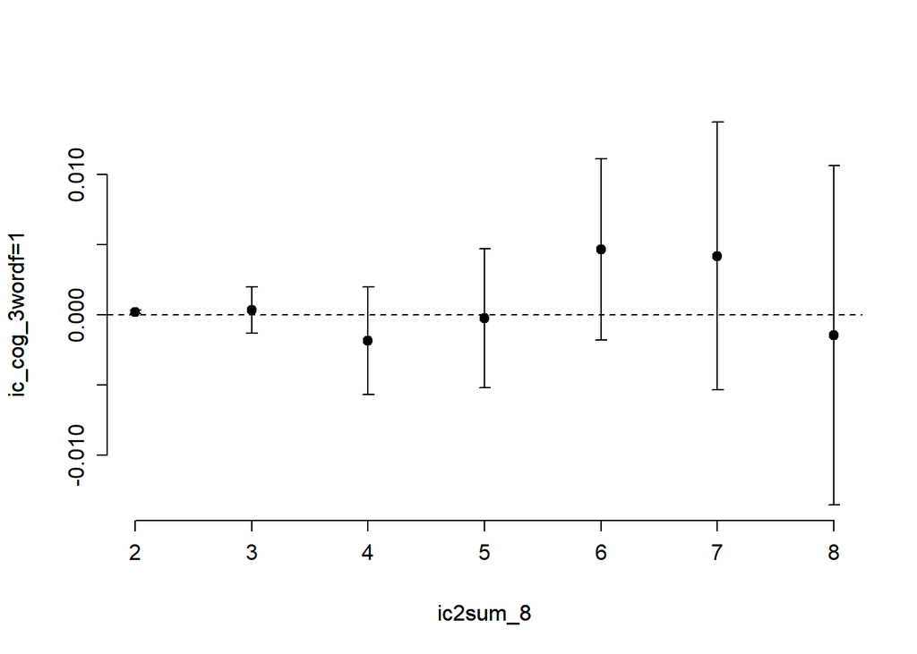

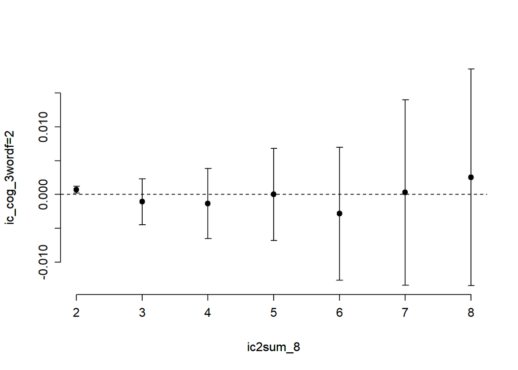

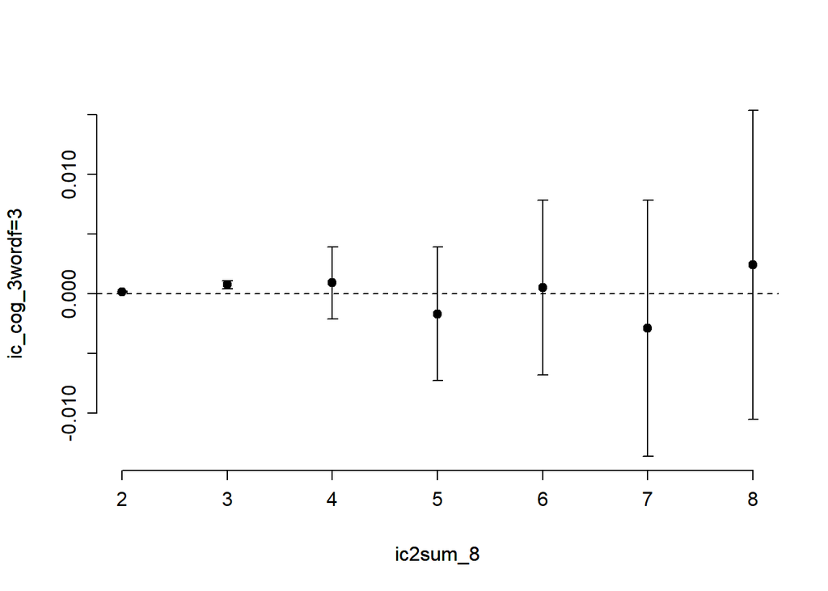

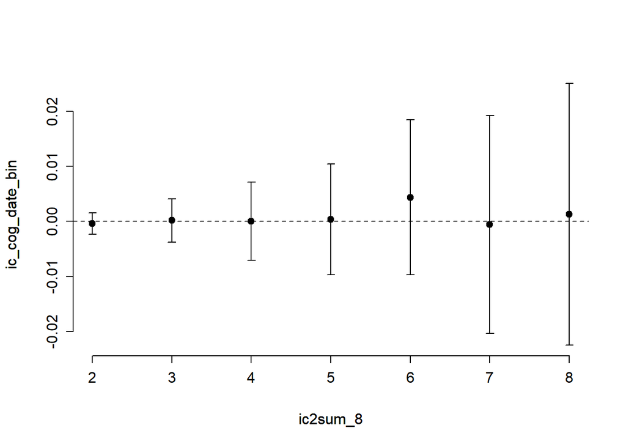

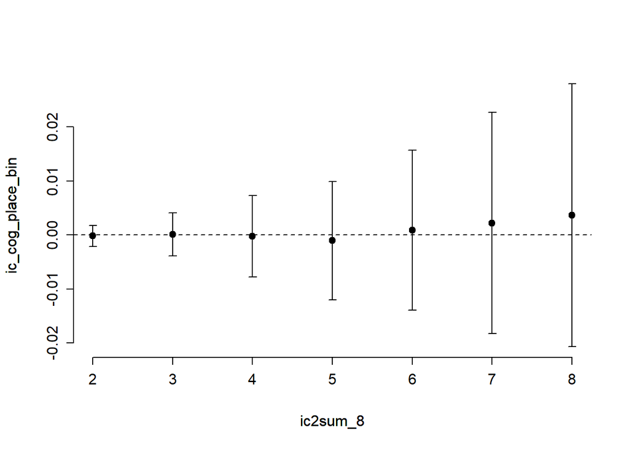

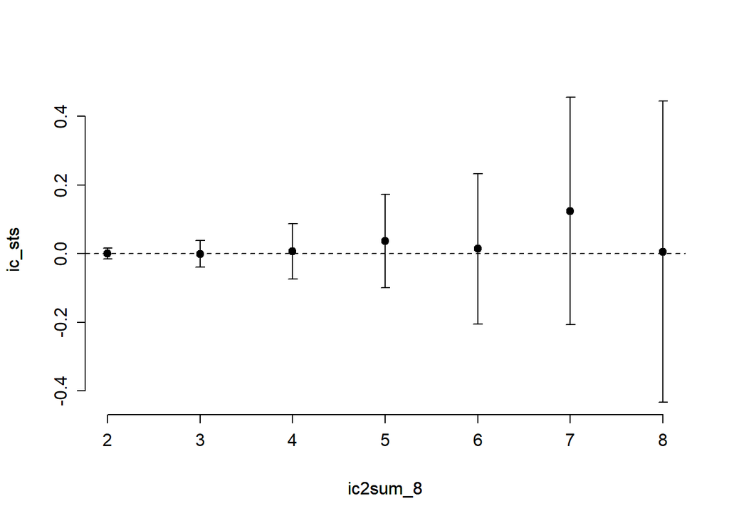

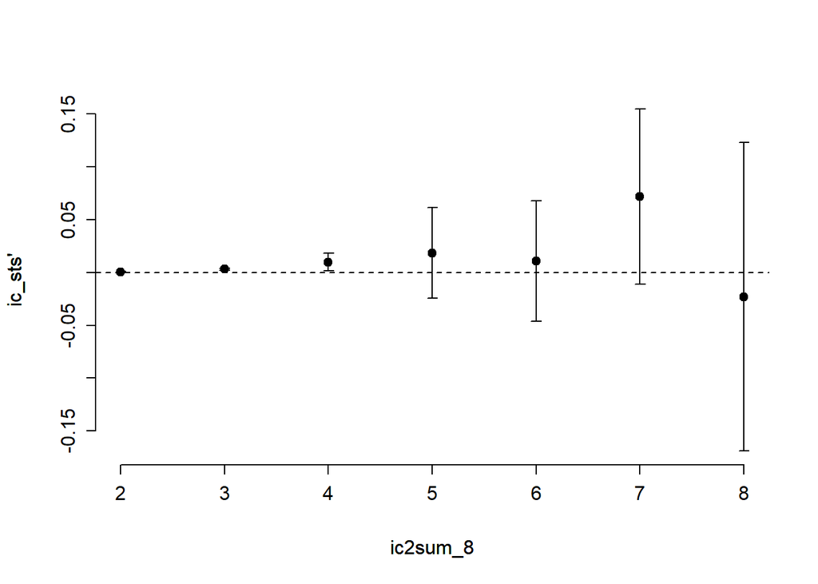

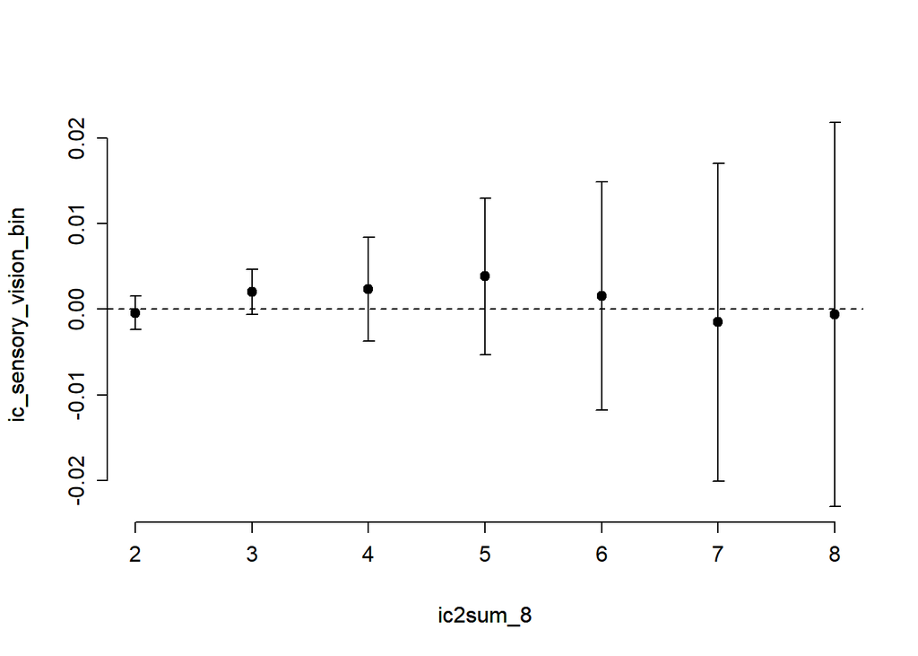

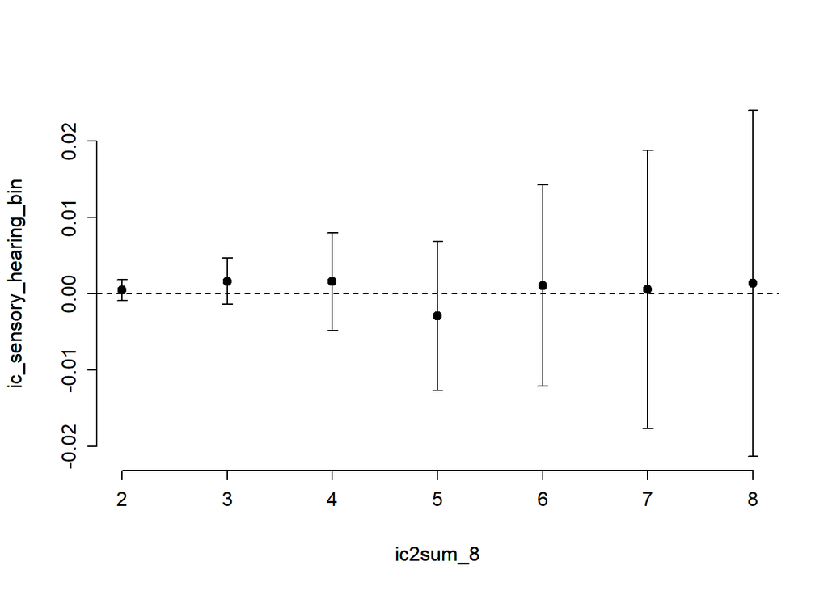

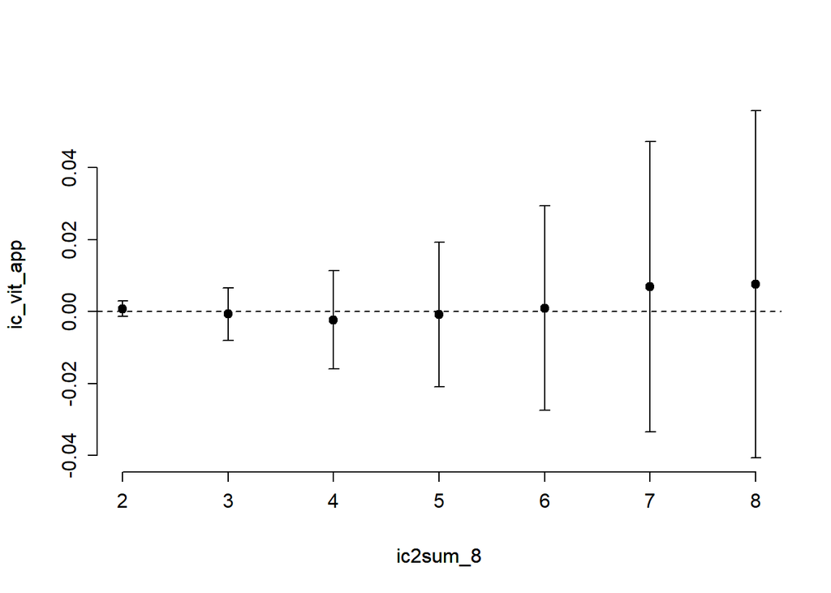

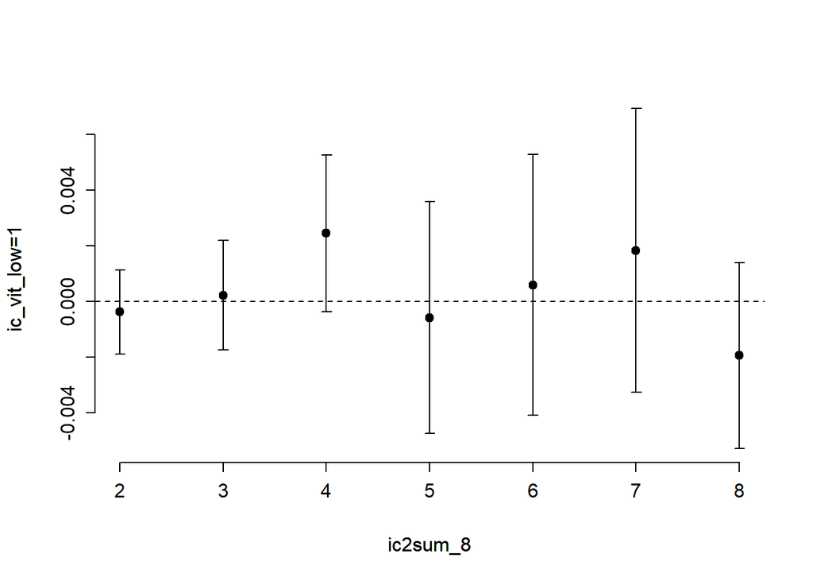

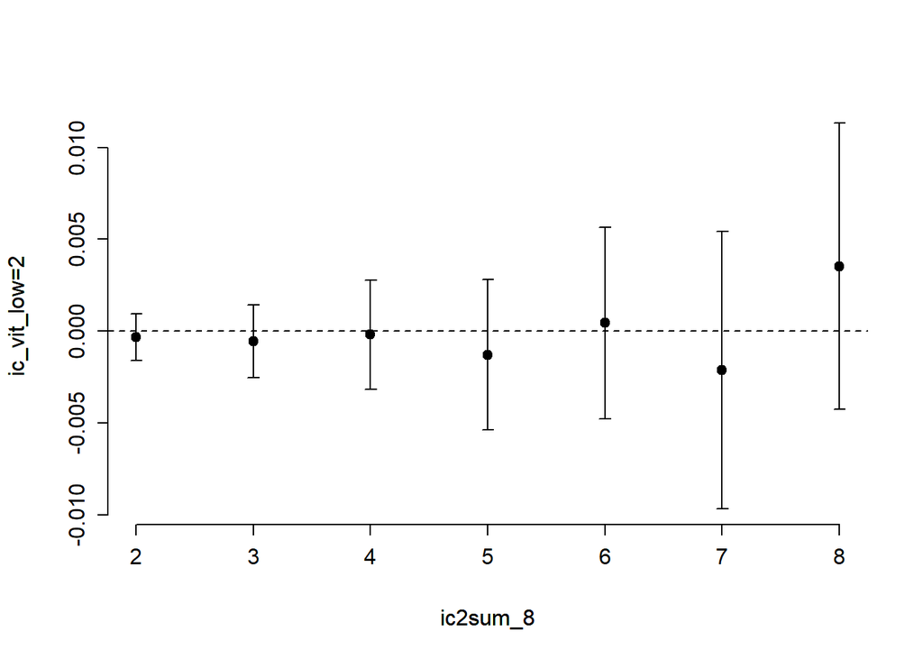

[3 more figures not shown]

```r
resid(mod_ics2, "score.binary", pl = TRUE)
```

## Model odds ratios

```r
summary(mod_ics2)
```

```
             Effects              Response : ic2sum_8

 Factor                 Low    High   Diff.  Effect  S.E.     Lower 0.95
 ic_cog_date_bin         0.000  1.000 1.0000 0.16794 0.206690 -0.23716
  Odds Ratio             0.000  1.000 1.0000 1.18290       NA  0.78887
 ic_cog_place_bin        0.000  1.000 1.0000 0.73222 0.287780  0.16817
  Odds Ratio             0.000  1.000 1.0000 2.07970       NA  1.18310
 ic_sts                 12.448 19.809 7.3604 0.91264 0.073751  0.76809
  Odds Ratio            12.448 19.809 7.3604 2.49090       NA  2.15560
 ic_sensory_vision_bin   0.000  1.000 1.0000 0.47003 0.136020  0.20345
  Odds Ratio             0.000  1.000 1.0000 1.60000       NA  1.22560
 ic_sensory_hearing_bin  0.000  1.000 1.0000 0.69087 0.146250  0.40423
  Odds Ratio             0.000  1.000 1.0000 1.99550       NA  1.49810
 ic_vit_app              0.000  2.000 2.0000 1.39850 0.298050  0.81435
  Odds Ratio             0.000  2.000 2.0000 4.04920       NA  2.25770
 ic_psy_hopeless_bin     0.000  1.000 1.0000 1.35370 0.242350  0.87870
  Odds Ratio             0.000  1.000 1.0000 3.87170       NA  2.40780
 ic_psy_worthless_bin    0.000  1.000 1.0000 1.72800 0.196590  1.34270
  Odds Ratio             0.000  1.000 1.0000 5.62910       NA  3.82920
 ic_cog_3wordf - 1:0     1.000  2.000     NA 0.88237 0.216670  0.45769
  Odds Ratio             1.000  2.000     NA 2.41660       NA  1.58040
 ic_cog_3wordf - 2:0     1.000  3.000     NA 0.95637 0.204630  0.55530
  Odds Ratio             1.000  3.000     NA 2.60220       NA  1.74250
 ic_cog_3wordf - 3:0     1.000  4.000     NA 1.10840 0.216470  0.68417
  Odds Ratio             1.000  4.000     NA 3.02960       NA  1.98210
 ic_vit_low - 1:0        1.000  2.000     NA 0.57289 0.431150 -0.27216
  Odds Ratio             1.000  2.000     NA 1.77340       NA  0.76173
 ic_vit_low - 2:0        1.000  3.000     NA 1.35490 0.380130  0.60983
  Odds Ratio             1.000  3.000     NA 3.87620       NA  1.84010
 ic_vit_low - 3:0        1.000  4.000     NA 1.80520 0.347120  1.12480
  Odds Ratio             1.000  4.000     NA 6.08090       NA  3.07960
 Upper 0.95
  0.57304
  1.77360
  1.29630
  3.65560
  1.05720
  2.87830
  0.73662
  2.08890
  0.97751
  2.65780
  1.98270
  7.26220
  1.82870
  6.22570
  2.11330
  8.27520
  1.30700
  3.69520
  1.35740
  3.88630
  1.53270
  4.63070
  1.41790
  4.12860
  2.09990
  8.16530
  2.48550
 12.00700
```

# Domain Importance

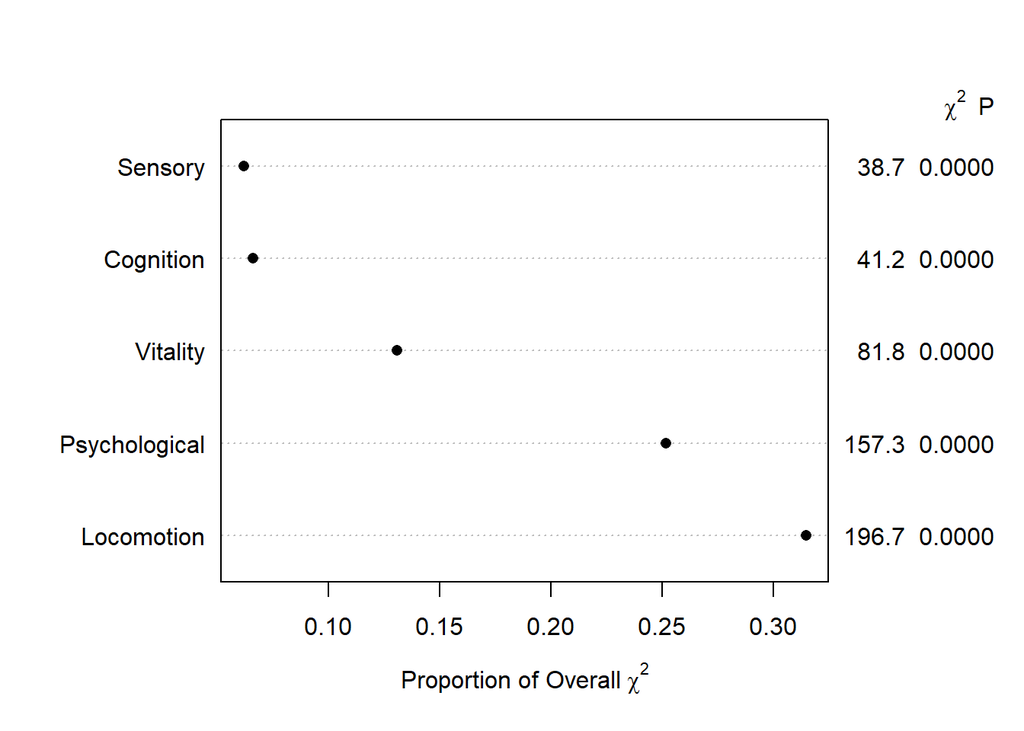

```r
an      <- anova(mod_ics2, test='LR')  # Overall Model LRx2 value
ic_cog  <- anova(mod_ics2,  ic_cog_3wordf  , ic_cog_date_bin , ic_cog_place_bin , test = 'LR')
ic_loco <- anova(mod_ics2,  ic_sts, test = 'LR')
ic_sens <- anova(mod_ics2, ic_sensory_vision_bin ,ic_sensory_hearing_bin, test = 'LR')
ic_psy  <- anova(mod_ics2,  ic_psy_hopeless_bin    , ic_psy_worthless_bin, test='LR')
ic_vit  <- anova(mod_ics2,  ic_vit_app ,  ic_vit_low,  test= 'LR')
s <- rbind(TOTAL = an[ 'TOTAL', ] ,
           Cognition = ic_cog['TOTAL',],
           Locomotion = ic_loco['TOTAL',],
           Sensory = ic_sens['TOTAL',],
           Psychological = ic_psy['TOTAL',],
           Vitality = ic_vit["TOTAL",])
class(s) <- 'anova.rms'
plot(s, what = "proportion chisq")
```

# Model Performance (Discrimination)

## Model-based IC score

```r
round(mod_ics2$stats["R2"], 2) # Nagelkerke R-squared (0.43)
```

```
  R2
0.43
```

```r
round((mod_ics2$stats["Model L.R."] - mod_ics2$stats["d.f."]) /
  mod_ics2$stats["Model L.R."], 2) #Van Houwelingen’s heuristic shrinkage (0.98)
```

```
Model L.R.
      0.98
```

```r
#' Step 1: Use the proportional odds model to predict a binary outcome
#  Compute linear predictor associated with (exceedance) Prob of impaired IC
pred_lp <- predict(mod_ics2, type = "lp", kint = 6)

# Step 2: Use Hmisc::rcorr.cens to estimate the apparent c-index
# - Extract the apparent c-index from this model to assess discrimination
x       <- rcorr.cens(-pred_lp, ippts_cleaned$ic_impaired)
se      <- round(x["S.D."]/2, 3)
cindex  <- x["C Index"]

# Step 3: Validate the original proportional odds model
# - Perform bootstrap internal validation to estimate optimism of the generalized c-index
#' refit PO model on Step 2 scores (with scores of 1 and 2 combined)
#' to overcome the validating an "ordinal model with sparse cells" error message
mod_ics2_refit <- update(mod_ics2, ic2sum_8_collapsed ~.)
myvalidate <- validate(mod_ics2_refit, group = mod_ics2_refit$y)
myvalidate <- unclass(myvalidate) %>% data.frame
Dxy_orig      <- myvalidate[1,1]
Dxy_corrected <- myvalidate[1,5]
optimism <- 0.5 * ( (Dxy_orig + 1) - (Dxy_corrected + 1) )


# Step 4: Adjust for optimism
# - Subtract the estimated optimism from the apparent c-index (found in Step 2)
# - This yields the optimism-corrected c-index
(cindex_op     <-  cindex - optimism)
```

```
  C Index
0.8169936
```

```r
(lcl = round(cindex_op  -  1.96*se, 3 ))
```

```
C Index
   0.79
```

```r
(ucl = round(cindex_op  +  1.96*se, 3 ))
```

```
C Index
  0.844
```

## Count-based IC score

```r
#' Comparison model
#' Count-based composite IC score is the predictor

mod_count <- lrm(ic_impaired ~ icsum_5 , x = T, y = T, data = ippts_cleaned)
round(mod_count$stats["R2"], 2) # Nagelkerke R-squared (0.32)
```

```
  R2
0.32
```

```r
x       <- rcorr.cens(predict(mod_count), mod_count$y)
se      <- round(x["S.D."]/2, 3)
cindex  <- x["C Index"]
myvalidate <- validate(mod_count)
myvalidate <- unclass(myvalidate) %>% data.frame
Dxy_orig      <- myvalidate[1,1]
Dxy_corrected <- myvalidate[1,5]
optimism <- 0.5 * ( (Dxy_orig + 1) - (Dxy_corrected + 1) )
(cindex_op     <-  cindex - optimism)
```

```
  C Index
0.7774362
```

```r
(lcl = round(cindex_op  -  1.96*se, 3 ))
```

```
C Index
   0.75
```

```r
(ucl = round(cindex_op  +  1.96*se, 3 ))
```

```
C Index
  0.805
```

# Model Performance (Calibration)

Acknowledgement  
Calibration plot codes were adapted from those generously shared by [Elias_Eythorsson](https://discourse.datamethods.org/t/critique-of-a-published-prediction-model/13882)

```r
# %%%%%%%%%%%%%%%%%%%%%%%%%%%%%% Step 1: Group comparison of Predicted and Observed Probs

cl <- makeCluster(detectCores()-2, type='PSOCK')
registerDoParallel(cl)
results <-
  foreach(i = 1:500,
          .errorhandling = "remove",
          .packages = c("dplyr", "rms")) %dopar% {
            df_mod    <- ippts_cleaned [sample(1:nrow(ippts_cleaned), replace = TRUE), ]
            fit_mod <- update(mod_ics2_refit, data = df_mod)
            cbind.data.frame(
              myprob  = plogis(predict(fit_mod, data = df_mod, kint  = 5)),
              outcome = df_mod$ic2sum_8_collapsed)
          }
registerDoSEQ()

df_pointrange <-
  cbind(
    iter = rep(1:length(results), each = nrow(ippts_cleaned)),
    do.call(rbind, results)) %>%
  mutate(outcome_binary = if_else(outcome >= 7, 1L, 0L)) %>%
  group_by(iter) %>%                         # per bootstrap iteration/sample
  mutate(bin1 = ntile(myprob, n = 5)) %>%   # place predicted prob into XX bins
  ungroup() %>%
  group_by(iter, bin1) %>%                   # within each iteration and each bin
  mutate(
    bin1_pred = mean(myprob),          ## compute mean predicted prob
    bin1_prob = mean(outcome_binary),  ## compute observed prob
  ) %>%
  ungroup() %>%
  arrange(iter, bin1) %>%
  mutate(across(starts_with("bin1_"), ~1 - .))



pointrange <-
  df_pointrange %>%
  group_by(bin1) %>%
  mutate(
    bin_pred = mean(bin1_pred),
    bin_prob = mean(bin1_prob),
    ll = quantile(bin1_prob, probs = c(0.025)),
    ul = quantile(bin1_prob, probs = c(0.975))
  ) %>%
  ungroup() %>%
  select(bin1, bin_pred, bin_prob, ll, ul) %>%
  distinct() %>%
  arrange(bin1)


# %%%%%%%%%%%%%%%%%%%%%%%%%%%%%%  Step 2:  Bootstrap optimism-corrected calibration curves

cl <- makeCluster(detectCores()-2, type='PSOCK')
registerDoParallel(cl)
cal_curve <-   foreach(i = 1:500,
                       .errorhandling = "remove",
                       .packages = c("dplyr", "rms")) %dopar% {

                         df_mod    <- ippts_cleaned [sample(1:nrow(ippts_cleaned), replace = TRUE), ]
                         fit_mod <- update(mod_ics2_refit, data = df_mod)
                         calibrate(fit_mod, kint = 5, predy = seq(0, 1, length = 100), B = 200)

                        }
registerDoSEQ()
```

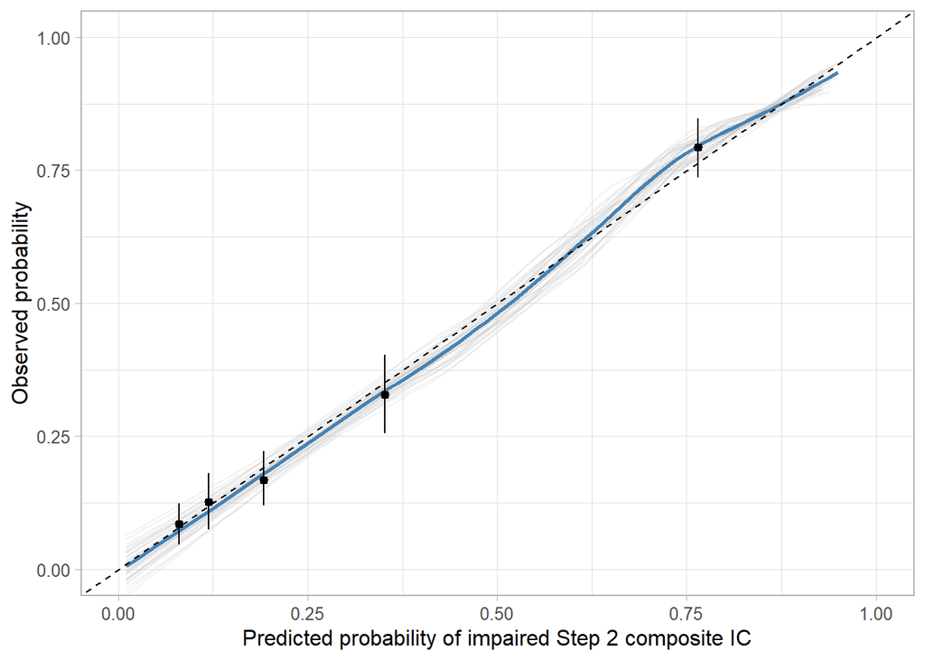

```r
# %%%%%%%%%%%%%%%%%%%%%%%%%%%%%% Generate calibration curves
cbind(
    iter = rep(1:length(cal_curve), each = 100),
    do.call(rbind, cal_curve)) %>%
  data.frame() %>%
 ggplot(aes(x = predy, y = calibrated.corrected)) +
  geom_line(aes(group = as.character(iter)), color = "gray", alpha = 0.2)+
  geom_smooth(aes(y = calibrated.corrected), se = FALSE, color = "steelblue") +
  geom_abline(lty = 2) +
  geom_pointrange(
    data = pointrange,
    aes(x = bin_pred, y = bin_prob, ymin = ll, ymax = ul),
    size = 0.3
  ) +
  labs(
    x = "Predicted probability of impaired Step 2 composite IC",
    y = "Observed probability"
  ) +
  coord_cartesian(xlim = c(0,1), ylim = c(0,1)) +
  theme_light(base_size = 12)
```

# Discriminative validity

This uses a customized `R` function (`auc_comp`) which computes (and contrasts) clinical-threshold specific AUCs from an ordinal model. See this [datamethods thread by Harrell.](https://discourse.datamethods.org/t/auc-for-different-decision-thresholds-in-an-ordinal-model/20429)

You can’t compare $c$ from a binary $Y$ to $c$ from a multi-level ordinal $Y$, as the latter is a more difficult discrimination task, reflected by systematically lower $c$. And don’t coarsen $Y$ by making a new binary variable. You can use the ordinal model to predict the probability of being at or above any level $y$ of $Y$ and compute $c$ against a temporarily binary $Y$ using that cutoff.

**`auc_comp`**

```r
auc_comp <- function(mydv,
                     mydata = ippts_cleaned,
                     ycut = NULL,
                     deci = 2 ) {


  mydata[["binary_dv"]] <- mydata[[mydv]]>=ycut
  model_pred1 <- lrm( as.formula(paste(mydv, "icsum_5", sep = "~")), x = T, y = T,  data = mydata)
  model_pred2 <- lrm( as.formula(paste(mydv, "ic_mod", sep = "~")), x = T, y = T,  data = mydata)
  mykint <- min(which(sort(unique(mydata[[mydv]])) >= ycut))
  pred_1 <- plogis(predict(model_pred1, kint =  mykint))
  pred_2 <- plogis(predict(model_pred2, kint =  mykint))



  #' compute c-stats (auc) with 95% CI
  myauc <- function(lrm_mod, mykint){

    x       <- rcorr.cens(na.omit(predict(lrm_mod, kint = mykint)),
                          (lrm_mod$y>=ycut)*1)
    se      <- round(x["S.D."]/2, 3)
    auc     <- x["C Index"]
    data.frame(
      auc = auc,
      auc_lo = auc - 1.96*se,
      auc_hi = auc + 1.96*se
    )
  }




  pred_auc <-
    tibble(
      myauc(model_pred2, mykint),
      myauc(model_pred1, mykint),
      .name_repair = "universal") %>%
    rename(model_auc = 1,  model_auc_lo = 2, model_auc_hi = 3,
           count_auc = 4,  count_auc_lo = 5, count_auc_hi = 6)



  # Paired Delong's Test
  roc1 <- with(mydata, roc(binary_dv, pred_1, percent=FALSE, ci=TRUE))
  roc2 <- with(mydata, roc(binary_dv, pred_2, percent=FALSE, ci=TRUE))
  roc_test <- roc.test(roc2, roc1, method="delong") ##P-value with 95% CI
  pdelong <-
    broom::glance(roc_test) %>%
    mutate(auc_diff = estimate1-estimate2,
           auc_diff1 = conf.low,
           auc_diff2 = conf.high,
           delong_pval = p.value) %>%
    dplyr::select(starts_with(c("auc", "delong"))) %>%
    mutate(delong_pval = ifelse(delong_pval < 0.001, "<0.001",
                                ifelse(delong_pval < 0.01, "<0.01",
                                       ifelse(delong_pval < 0.05, "<0.05",
                                              sprintf("%.3f", delong_pval)))))

  #' consolidate all results
  vars_to_clean <- c("rhs_auc", "lhs_auc")
  allstats <-
    cbind(pred_auc, pdelong) %>%
    mutate(across(!contains("pval"), ~round(.x, 2)))


  structure(list(allstats = allstats))

}
```

```r
bind_rows(
  list(
    Frailty  = auc_comp(mydv = "rfi", ycut=0.15)$allstats,
    Sarcopenia = auc_comp(mydv = "sarcf5", ycut=4)$allstats,
    RLSM = auc_comp(mydv = "lsa", ycut=60.5)$allstats,
    Self_reported_health = auc_comp(mydv = "srh", ycut=4)$allstats),
  .id = "Outcome")
```

```
               Outcome model_auc model_auc_lo model_auc_hi count_auc
1              Frailty      0.85         0.82         0.87      0.80
2           Sarcopenia      0.85         0.80         0.89      0.73
3                 RLSM      0.74         0.68         0.79      0.68
4 Self_reported_health      0.63         0.59         0.67      0.61
  count_auc_lo count_auc_hi auc_diff auc_diff1 auc_diff2 delong_pval
1         0.77         0.83     0.05      0.03      0.07      <0.001
2         0.67         0.79     0.12      0.08      0.16      <0.001
3         0.63         0.74     0.05      0.02      0.08       <0.01
4         0.58         0.65     0.02     -0.01      0.04       0.200
```

# Decision Curve Analysis

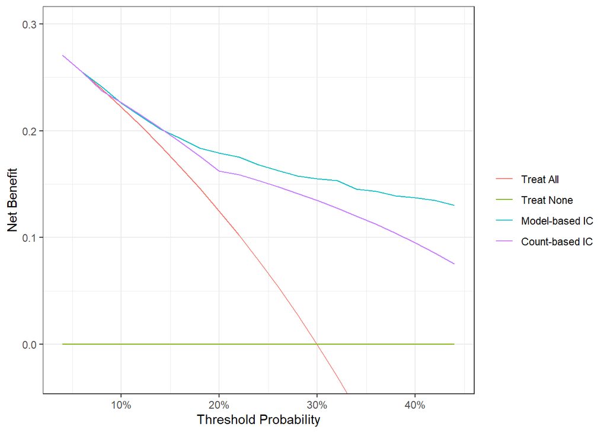

```r
# Predicted prob of impaired Step 2 composite IC
ippts_cleaned$prob_model      <- 1- plogis(predict(mod_ics2,  kint = 6))
ippts_cleaned$prob_count <- plogis(predict(mod_count, kint = 1))



(dca_ic <-
    dca(ic_impaired  ~
          prob_model +
          prob_count,
        data = ippts_cleaned,
        thresholds = seq(0.04, 0.44, 0.02),
        label = list(
          prob_count  = "Count-based IC",
          prob_model = "Model-based IC")))
```

# Nomogram

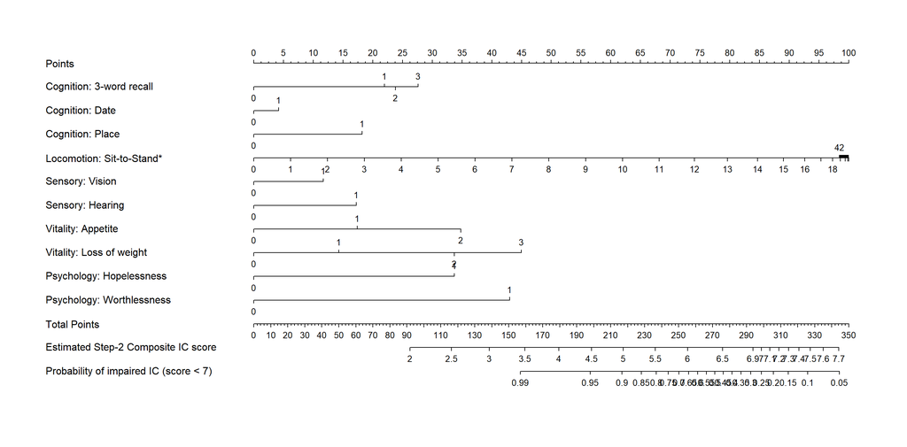

```r
fun_mean_ic  <- Mean(mod_ics2)
fun_1deficit <- function(x) 1- plogis(x - mod_ics2$coef[1] + mod_ics2$coef[6])
fun_list     <- list(c(seq(0.5, 6.5, 0.5), 6.9, 7, 7.1, 7.2, 7.3, 7.4, 7.5, 7.6, 7.7, 7.8),
                     c(0.025, seq(0.05, 0.95, 0.05), 0.99))


newlabels <-
  c(ic_cog_3wordf = "Cognition: 3-word recall",
  ic_cog_date_bin = "Cognition: Date ",
  ic_cog_place_bin= "Cognition: Place",
  ic_sts = "Locomotion: Sit-to-Stand*",
  ic_sensory_vision_bin = "Sensory: Vision",
  ic_sensory_hearing_bin = "Sensory: Hearing",
  ic_vit_app = "Vitality: Appetite",
  ic_vit_low = "Vitality: Loss of weight",
  ic_psy_hopeless_bin = "Psychology: Hopelessness",
  ic_psy_worthless_bin= "Psychology: Worthlessness")

f <- Newlabels(mod_ics2, newlabels)

g <- nomogram(f,
         lp = F,
         maxscale = 100,
         nint= 30,
         fun=list('Estimated Step-2 Composite IC score' = fun_mean_ic,
                  'Probability of impaired IC (score < 7)'= fun_1deficit),
         fun.at = fun_list)

plot(g)
```